# Regression diagnostics: SHIN checks for linear regression

## H: Homoscedasticity (Equal Variance)

The question here is: is the spread of the outcome similar in each group?

For this, we read the **Homogeneity of variance** panel.

A flat green line means even spread across groups.

### Knee rehabilitation program (equal spread)

Knee range-of-motion gain (degrees) for patients on one of three rehabilitation programs.

```r
cat_multi <- data.frame(
  program = factor(rep(c("standard", "intensive", "aquatic"), each = 18),
                   levels = c("standard", "intensive", "aquatic")),
  rom_gain = c(40.2, 28.6, 34.2, 35.8, 34.4, 31.4, 41.1, 31.4, 44.1, 31.6, 39.8, 45.7, 23.7, 30.3, 31.2, 35.8, 30.3, 16.1,
               30.4, 52.9, 43.2, 34.3, 44, 52.3, 56.4, 42.4, 43.5, 34.4, 47.8, 41.2, 47.7, 49.2, 51.2, 41.3, 48, 34.7,
               34.3, 33.9, 24.5, 39.2, 40.2, 36.8, 43.5, 34.6, 30.8, 41.6, 34.1, 47.7, 36.4, 42.9, 40.9, 34.3, 48.5, 42.9)
)
```

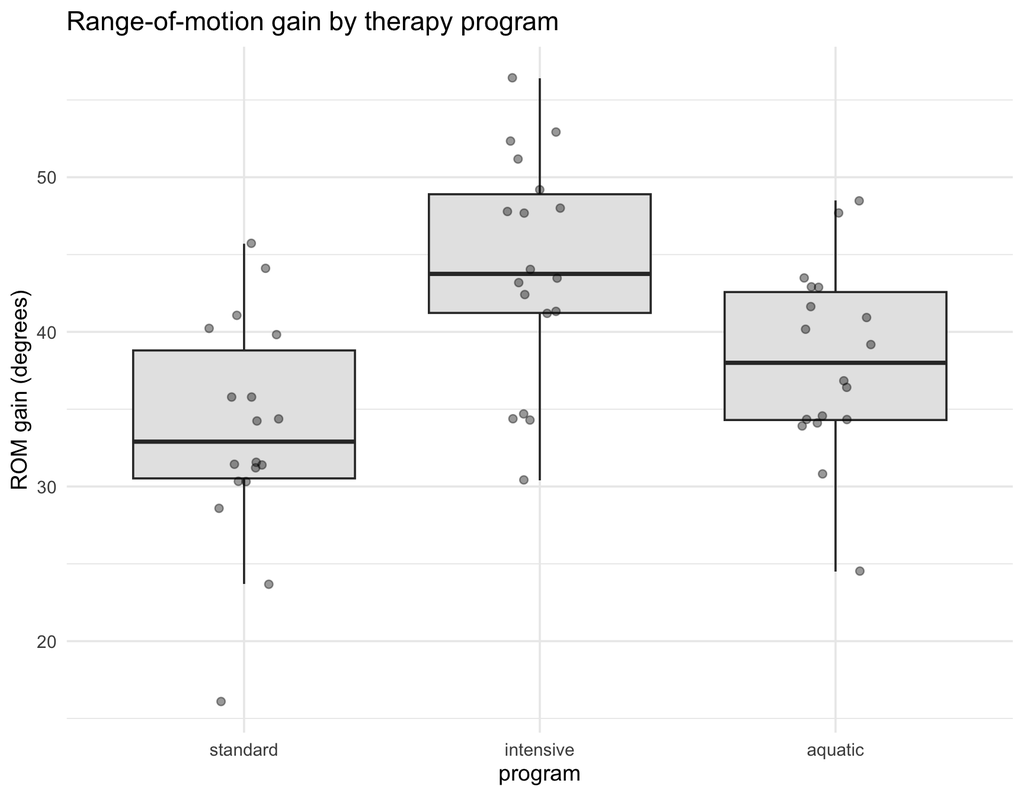

```r
ggplot(cat_multi, aes(program, rom_gain)) +
  geom_boxplot(outlier.shape = NA, fill = "grey90") +
  geom_jitter(width = 0.12, alpha = 0.4, size = 2) +
  labs(title = "Range-of-motion gain by therapy program", y = "ROM gain (degrees)") +
  theme_minimal(base_size = 14)
```

```r
cat_multi_model <- lm(rom_gain ~ program, data = cat_multi)
summary(cat_multi_model)
```

```
##
## Call:
## lm(formula = rom_gain ~ program, data = cat_multi)
##
## Residuals:
##      Min       1Q   Median       3Q      Max
## -17.5500  -3.5167  -0.4111   4.7278  12.2389
##
## Coefficients:
##                  Estimate Std. Error t value Pr(>|t|)
## (Intercept)        33.650      1.615  20.831  < 2e-16 ***
## programintensive   10.511      2.284   4.601 2.81e-05 ***
## programaquatic      4.522      2.284   1.980   0.0532 .
## ---
## Signif. codes:  0 '***' 0.001 '**' 0.01 '*' 0.05 '.' 0.1 ' ' 1
##
## Residual standard error: 6.853 on 51 degrees of freedom
## Multiple R-squared:  0.2947, Adjusted R-squared:  0.267
## F-statistic: 10.65 on 2 and 51 DF,  p-value: 0.0001361
```

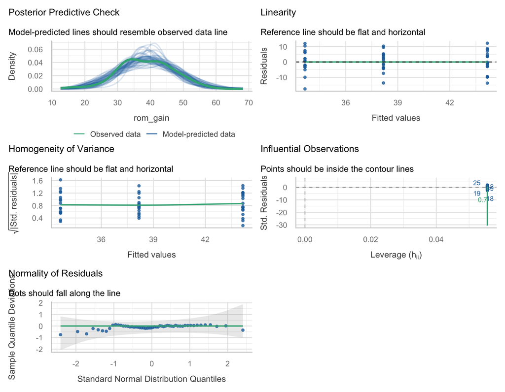

```r
check_model(cat_multi_model)
```

The default output includes all four SHIN panels. Linearity and Influential observations do not apply here.

To show only the homogeneity panel:

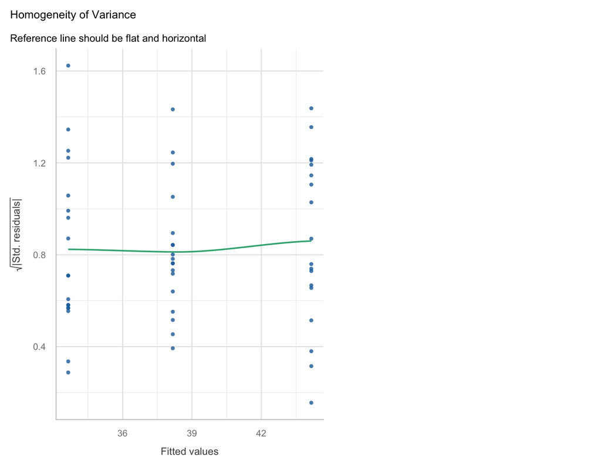

```r
check_model(cat_multi_model, check = "homogeneity")
```

The green line is reasonably flat, indicating similar spread across groups.

### Length of stay by ward type (unequal spread)

Hospital length of stay (days) for patients on general, surgical, or ICU wards.

General and surgical stays cluster tightly. ICU stays vary much more widely.

```r
cat_poly_hom_bad <- data.frame(
  ward = factor(rep(c("general", "surgical", "icu"), each = 18),
                levels = c("general", "surgical", "icu")),
  los_days = c(3.4, 6.7, 5.1, 4.3, 3.8, 6, 3.9, 3.8, 3.8, 4.3, 3.2, 4.1, 4.8, 3.9, 3.1, 3, 4.9, 6.2,
               6.2, 8.1, 7.3, 5.8, 9.2, 6.5, 7.8, 10.1, 6.9, 8.4, 7.1, 9.5, 6.3, 8.8, 7.6, 10.3, 6.8, 9.1,
               11.2, 0.5, 4.4, 7, 4, 2.3, 4.6, 9.5, 8.1, 2.9, 10.7, 0.5, 9.4, 1.3, 9.9, 4.6, 2.4, 3.4)
)
```

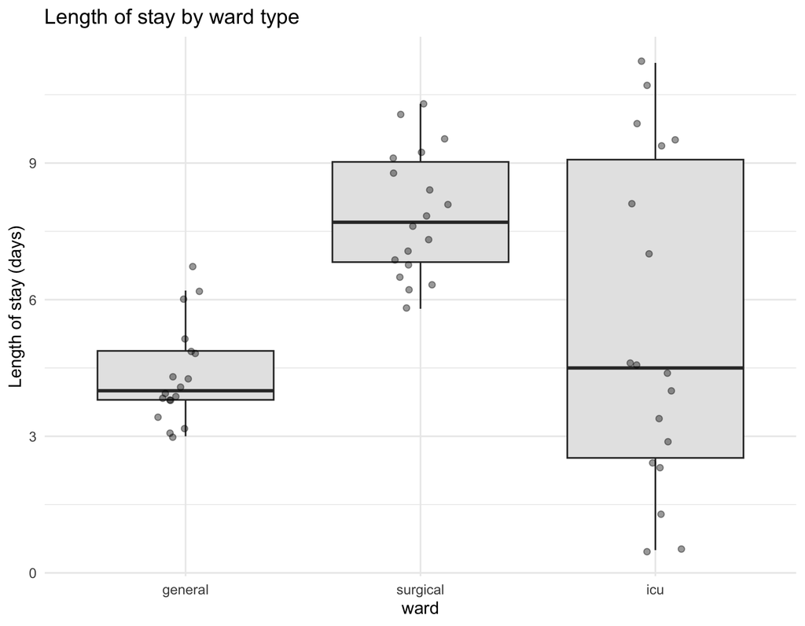

```r
ggplot(cat_poly_hom_bad, aes(ward, los_days)) +
  geom_boxplot(outlier.shape = NA, fill = "grey90") +
  geom_jitter(width = 0.12, alpha = 0.4, size = 2) +
  labs(title = "Length of stay by ward type", y = "Length of stay (days)") +
  theme_minimal(base_size = 14)
```

```r
cat_poly_hom_bad_model <- lm(los_days ~ ward, data = cat_poly_hom_bad)
summary(cat_poly_hom_bad_model)
```

```
##
## Call:
## lm(formula = los_days ~ ward, data = cat_poly_hom_bad)
##
## Residuals:
##    Min     1Q Median     3Q    Max
## -4.872 -1.225 -0.450  1.297  5.828
##
## Coefficients:
##              Estimate Std. Error t value Pr(>|t|)
## (Intercept)    4.3500     0.5471   7.951 1.73e-10 ***
## wardsurgical   3.5278     0.7737   4.559 3.24e-05 ***
## wardicu        1.0222     0.7737   1.321    0.192
## ---
## Signif. codes:  0 '***' 0.001 '**' 0.01 '*' 0.05 '.' 0.1 ' ' 1
##
## Residual standard error: 2.321 on 51 degrees of freedom
## Multiple R-squared:  0.3015, Adjusted R-squared:  0.2741
## F-statistic: 11.01 on 2 and 51 DF,  p-value: 0.0001063
```

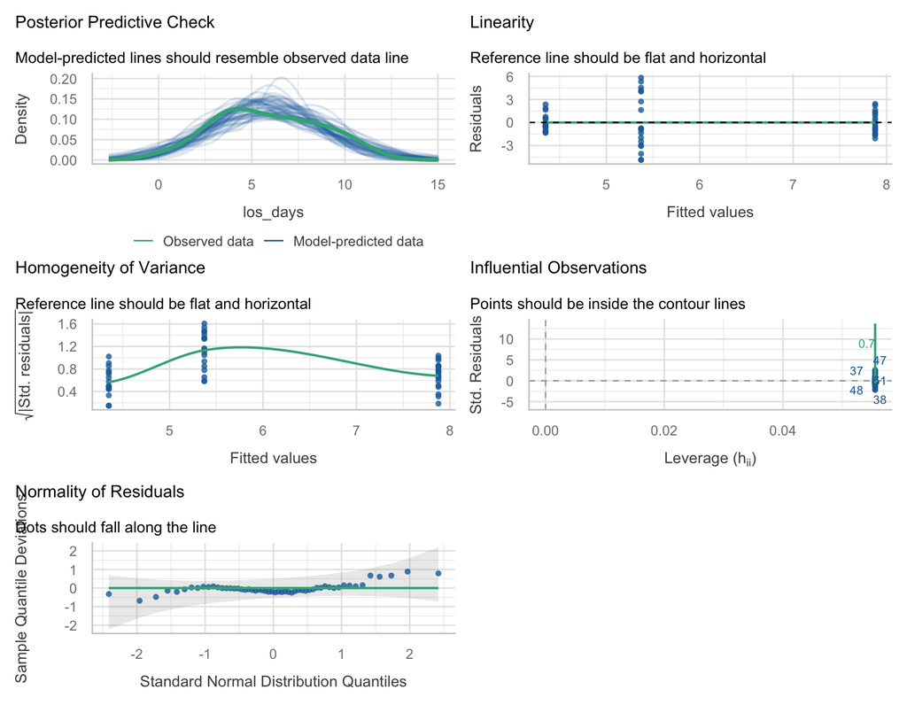

```r
check_model(cat_poly_hom_bad_model)
```

To show only the homogeneity panel:

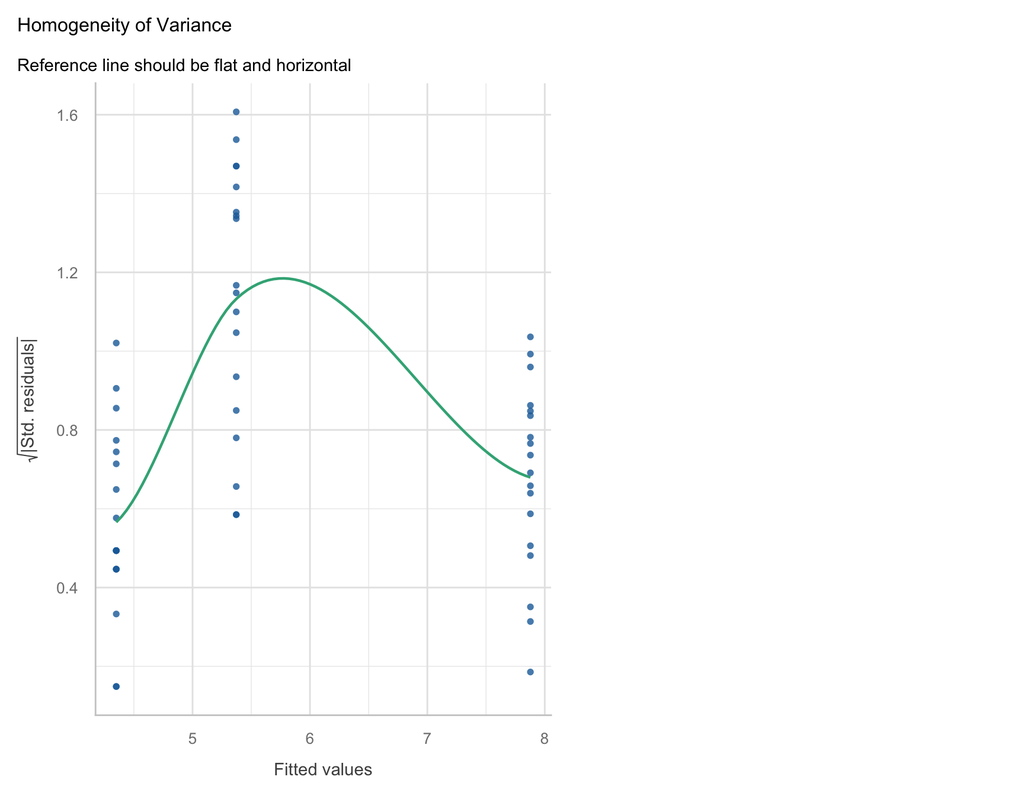

```r
check_model(cat_poly_hom_bad_model, check = "homogeneity")
```

```r
cat_poly_hom_bad %>%
  group_by(ward) %>%
  summarise(mean = mean(los_days), sd = sd(los_days), n = n())
```

| ward | mean | sd | n |
| --- | --- | --- | --- |
| general | 4.350000 | 1.077169 | 18 |
| surgical | 7.877778 | 1.382902 | 18 |
| icu | 5.372222 | 3.618223 | 18 |

The ICU standard deviation is much larger than the others.

```r
check_heteroscedasticity(cat_poly_hom_bad_model)
```

```
## OK: Error variance appears to be homoscedastic (p = 0.341).
```

**One way to fix it:** for group comparisons, the most common approach is to use a method that does not assume equal variances, such as Welch’s ANOVA (`oneway.test()` in base R, which relaxes the equal-variance assumption). Transforming the outcome can also help if the larger spread occurs in the group with the larger mean.

### Practice

Pain score reduction (points) for patients on one of three analgesic regimens.

Fit the model, look at the boxplot, then read the **Homogeneity of variance** panel. Use `check_model(model, check = "homogeneity")` if you want to hide the other panels. Is the spread similar across groups?

```r
practice_6 <- data.frame(
  regimen = factor(rep(c("standard", "extended", "combination"), each = 18),
                   levels = c("standard", "extended", "combination")),
  pain_reduction = c(3.2, 4.1, 3.8, 4.5, 3.5, 4.2, 3.9, 4.0, 3.6, 4.3, 3.7, 4.4, 3.4, 4.1, 3.8, 4.2, 3.9, 4.0,
                   5.1, 6.2, 5.8, 6.5, 5.4, 6.0, 5.6, 6.3, 5.2, 6.1, 5.7, 6.4, 5.5, 6.0, 5.9, 6.2, 5.3, 6.1,
                   4.8, 12.5, 5.2, 11.8, 4.5, 13.1, 5.0, 12.2, 4.9, 11.5, 5.3, 12.8, 4.7, 13.4, 5.1, 11.9, 4.6, 12.6)
)
```

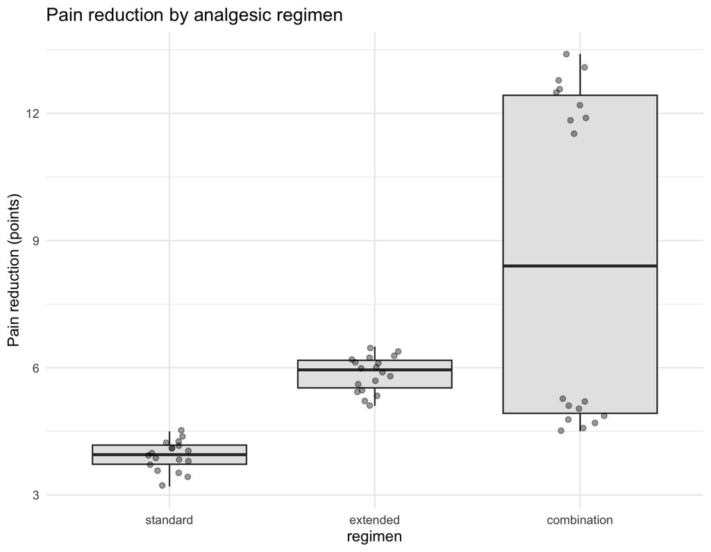

```r
ggplot(practice_6, aes(regimen, pain_reduction)) +
  geom_boxplot(outlier.shape = NA, fill = "grey90") +
  geom_jitter(width = 0.12, alpha = 0.4, size = 2) +
  labs(title = "Pain reduction by analgesic regimen", y = "Pain reduction (points)") +
  theme_minimal(base_size = 14)
```

```r
practice_6_model <- lm(pain_reduction ~ regimen, data = practice_6)
summary(practice_6_model)
```

```
##
## Call:
## lm(formula = pain_reduction ~ regimen, data = practice_6)
##
## Residuals:
##     Min      1Q  Median      3Q     Max
## -4.1611 -0.5042  0.0639  0.4319  4.7389
##
## Coefficients:
##                    Estimate Std. Error t value Pr(>|t|)
## (Intercept)          3.9222     0.5358   7.321 1.70e-09 ***
## regimenextended      1.9278     0.7577   2.544    0.014 *
## regimencombination   4.7389     0.7577   6.254 8.18e-08 ***
## ---
## Signif. codes:  0 '***' 0.001 '**' 0.01 '*' 0.05 '.' 0.1 ' ' 1
##
## Residual standard error: 2.273 on 51 degrees of freedom
## Multiple R-squared:  0.4369, Adjusted R-squared:  0.4148
## F-statistic: 19.78 on 2 and 51 DF,  p-value: 4.366e-07
```

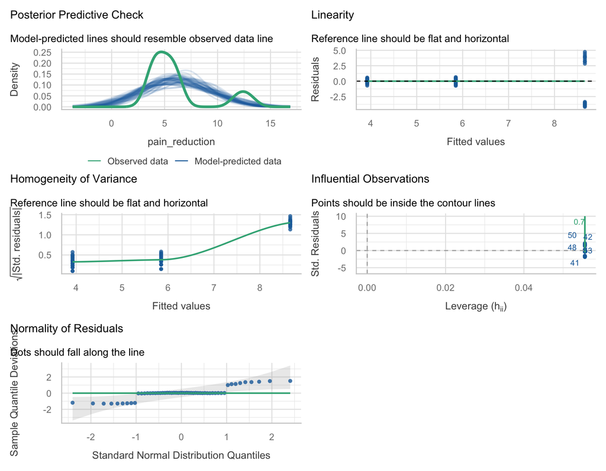

```r
check_model(practice_6_model)
```

**Your answer here:**

## N: Normality of Residuals

**The question:** are the residuals roughly bell-shaped?

We read the **Normality of residuals** panel (the Q-Q plot), as with a continuous predictor.

### Knee rehabilitation program (normal residuals)

Using the three-group rehabilitation data from above.

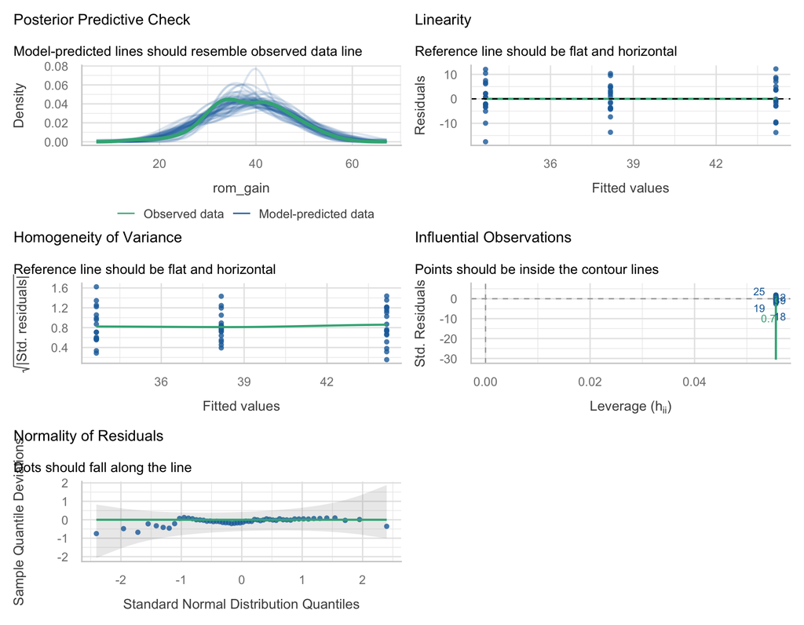

```r
check_model(cat_multi_model)
```

To show only the normality panel:

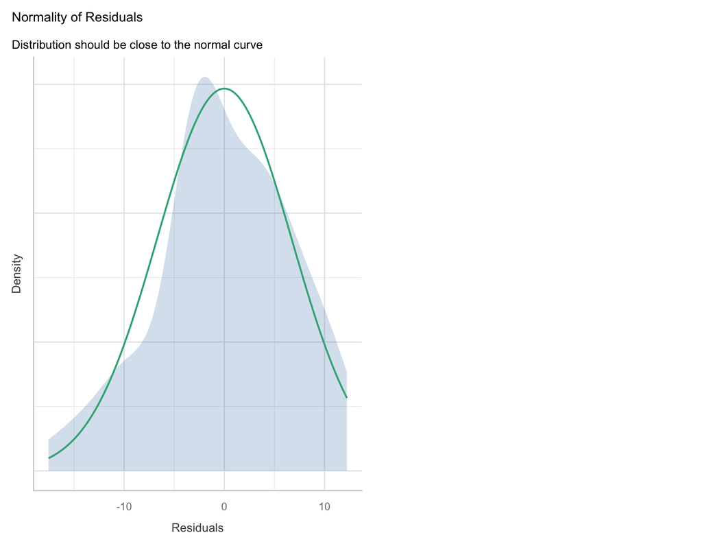

```r
check_model(cat_multi_model, check = "normality")
```

The Q-Q points lie close to the reference line across the range.

### CRP level by clinic site (non-normal residuals)

C-reactive protein (mg/L) measured at three clinic sites.

```r
cat_poly_norm_bad <- data.frame(
  site = factor(rep(c("clinic_a", "clinic_b", "clinic_c"), each = 18),
                levels = c("clinic_a", "clinic_b", "clinic_c")),
  crp_mg = c(2.1, 3.4, 2.8, 4.2, 3.1, 2.5, 3.8, 2.9, 3.5, 4.0, 2.7, 3.3, 2.4, 3.6, 2.8, 3.2, 2.6, 18.5,
             2.3, 3.1, 2.9, 3.7, 2.6, 3.4, 3.0, 2.8, 3.5, 2.5, 3.2, 2.7, 3.9, 2.4, 3.1, 2.8, 3.6, 16.2,
             2.5, 3.0, 2.7, 3.3, 2.9, 3.8, 2.6, 3.4, 2.8, 3.1, 2.4, 3.5, 2.7, 3.2, 2.5, 3.6, 2.9, 19.8)
)
```

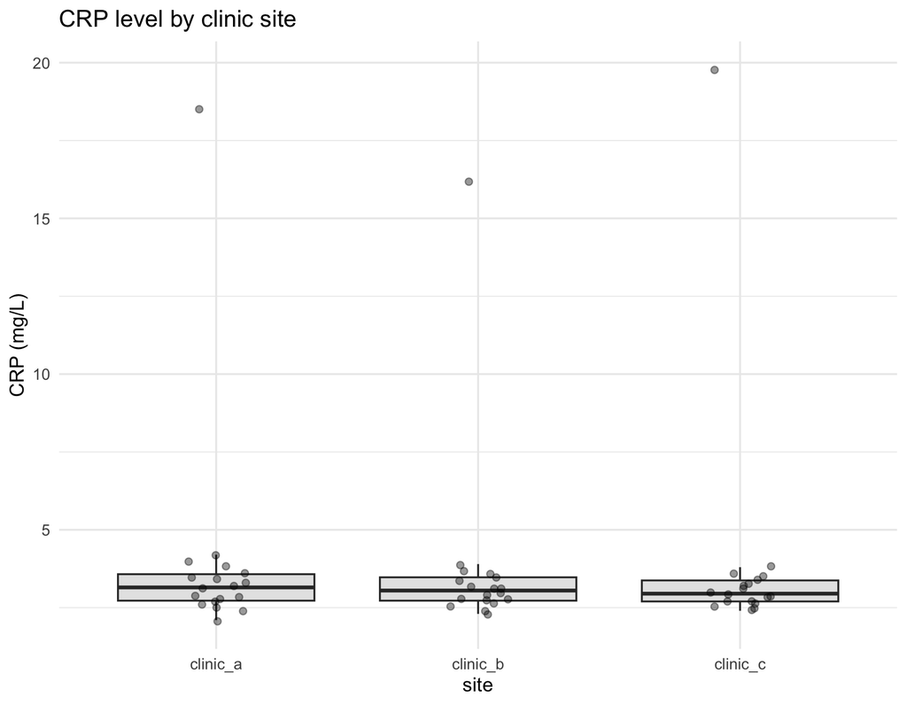

```r
ggplot(cat_poly_norm_bad, aes(site, crp_mg)) +
  geom_boxplot(outlier.shape = NA, fill = "grey90") +
  geom_jitter(width = 0.12, alpha = 0.4, size = 2) +
  labs(title = "CRP level by clinic site", y = "CRP (mg/L)") +
  theme_minimal(base_size = 14)
```

```r
cat_poly_norm_bad_model <- lm(crp_mg ~ site, data = cat_poly_norm_bad)
summary(cat_poly_norm_bad_model)
```

```
##
## Call:
## lm(formula = crp_mg ~ site, data = cat_poly_norm_bad)
##
## Residuals:
##     Min      1Q  Median      3Q     Max
## -1.8667 -1.2125 -0.8444 -0.3819 15.8722
##
## Coefficients:
##              Estimate Std. Error t value Pr(>|t|)
## (Intercept)   3.96667    0.85183   4.657 2.33e-05 ***
## siteclinic_b -0.20556    1.20467  -0.171    0.865
## siteclinic_c -0.03889    1.20467  -0.032    0.974
## ---
## Signif. codes:  0 '***' 0.001 '**' 0.01 '*' 0.05 '.' 0.1 ' ' 1
##
## Residual standard error: 3.614 on 51 degrees of freedom
## Multiple R-squared:  0.000644,   Adjusted R-squared:  -0.03855
## F-statistic: 0.01643 on 2 and 51 DF,  p-value: 0.9837
```

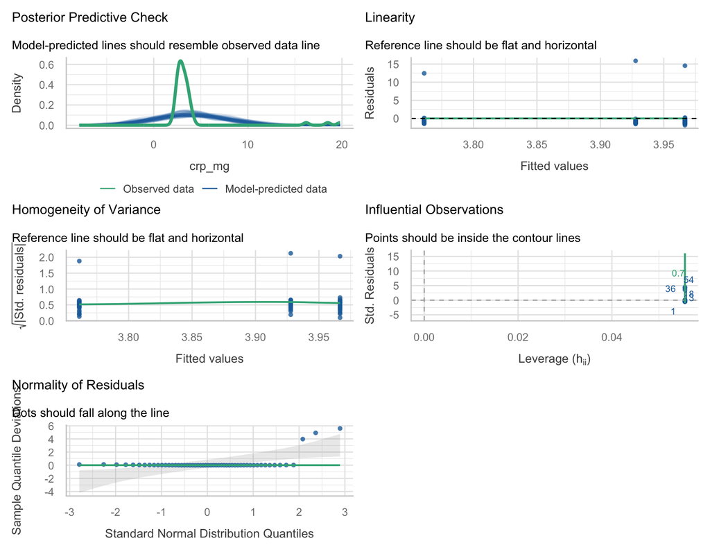

```r
check_model(cat_poly_norm_bad_model)
```

To show only the normality panel:

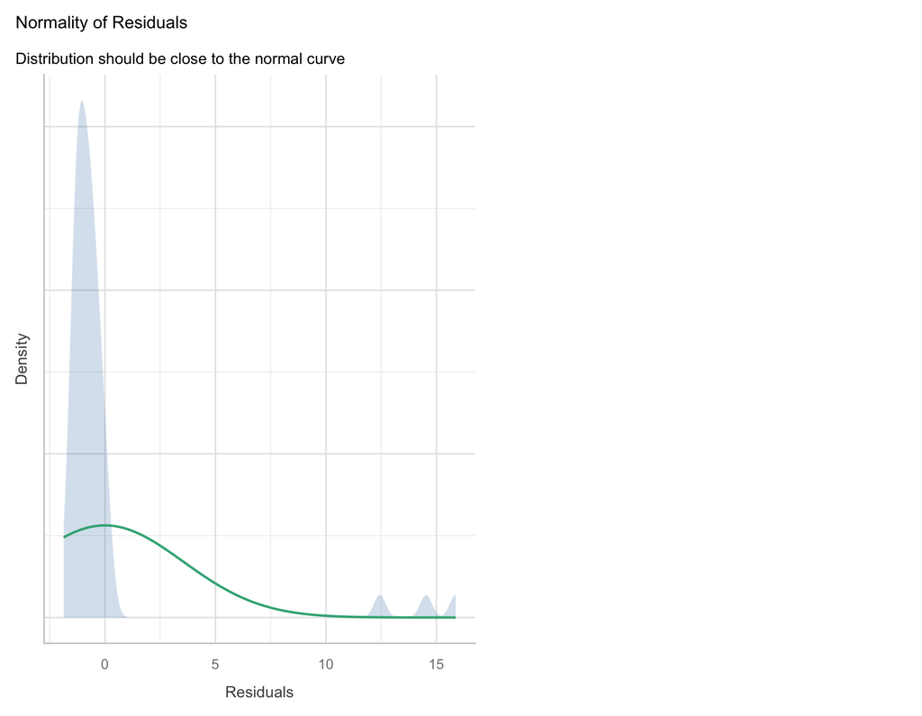

```r
check_model(cat_poly_norm_bad_model, check = "normality")
```

In the *Normality* Q-Q panel, the points bend away from the reference line at the upper end.

That is the long right tail from the high CRP values.

Because the Q-Q plot already shows the bend, we can confirm with the formal test:

```r
check_normality(cat_poly_norm_bad_model)
```

[output not shown]

**One way to fix it:** first inspect the extreme values; a value like CRP = 18.5 among values around 3 may be a recording error. If the values are genuine, a log transformation of the outcome is the usual first step for a right-skewed biomarker like CRP.

### Practice

Serum albumin (g/dL) for patients in one of three nutritional support programs.

Fit the model, look at the boxplot, then read the **Normality of residuals** panel. Use `check_model(model, check = "normality")` if you want to hide the other panels. Are the residuals roughly bell-shaped?

```r
practice_7 <- data.frame(
  program = factor(rep(c("standard", "high_protein", "enteral"), each = 18),
                   levels = c("standard", "high_protein", "enteral")),
  albumin = c(3.2, 3.5, 3.4, 3.6, 3.3, 3.5, 3.4, 3.7, 3.3, 3.6, 3.5, 3.4, 3.3, 3.6, 3.5, 3.4, 3.7, 3.3,
              3.4, 3.6, 3.5, 3.7, 3.4, 3.6, 3.5, 3.8, 3.4, 3.6, 3.5, 3.7, 3.4, 3.6, 3.5, 3.7, 3.4, 3.6,
              3.3, 3.5, 3.4, 3.6, 3.5, 3.4, 3.7, 3.3, 3.5, 3.6, 3.4, 3.5, 3.3, 3.6, 3.4, 3.5, 3.7, 3.3)
)
```

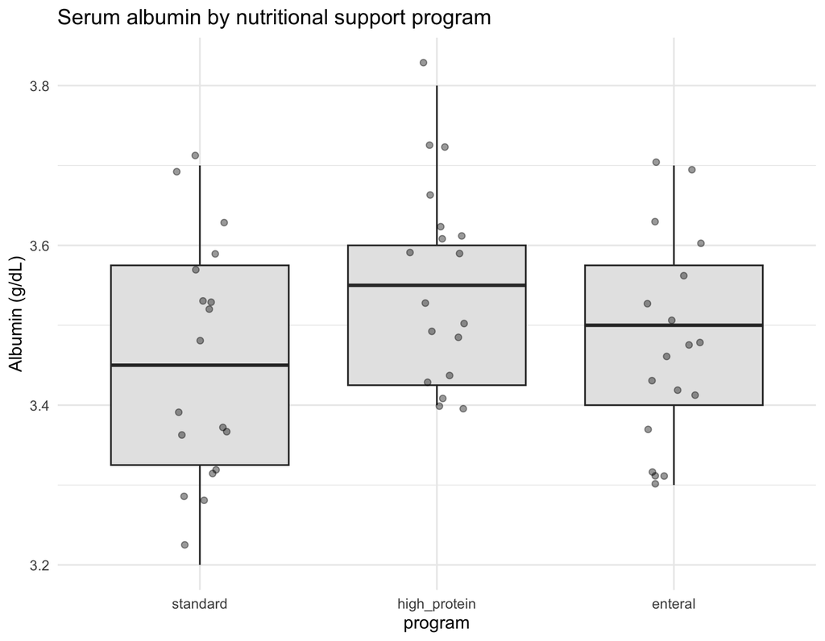

```r
ggplot(practice_7, aes(program, albumin)) +
  geom_boxplot(outlier.shape = NA, fill = "grey90") +
  geom_jitter(width = 0.12, alpha = 0.4, size = 2) +
  labs(title = "Serum albumin by nutritional support program", y = "Albumin (g/dL)") +
  theme_minimal(base_size = 14)
```

```r
practice_7_model <- lm(albumin ~ program, data = practice_7)
summary(practice_7_model)
```

```
##
## Call:
## lm(formula = albumin ~ program, data = practice_7)
##
## Residuals:
##      Min       1Q   Median       3Q      Max
## -0.25556 -0.13056  0.02778  0.10833  0.25000
##
## Coefficients:
##                     Estimate Std. Error t value Pr(>|t|)
## (Intercept)          3.45556    0.03175 108.827   <2e-16 ***
## programhigh_protein  0.09444    0.04491   2.103   0.0404 *
## programenteral       0.01667    0.04491   0.371   0.7121
## ---
## Signif. codes:  0 '***' 0.001 '**' 0.01 '*' 0.05 '.' 0.1 ' ' 1
##
## Residual standard error: 0.1347 on 51 degrees of freedom
## Multiple R-squared:  0.08995,    Adjusted R-squared:  0.05426
## F-statistic:  2.52 on 2 and 51 DF,  p-value: 0.0904
```

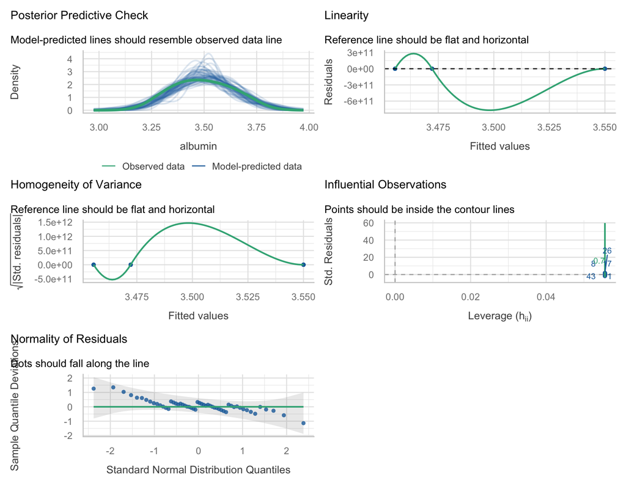

```r
check_model(practice_7_model)
```

**Your answer here:**

# Categorical binary predictor

A binary predictor has exactly two levels (for example, exposed vs. unexposed).

Regression with one binary categorical predictor is the same model as an **independent-samples t-test**. The regression coefficient is the difference between the two group means.

So the assumptions are the same as for the usual pooled t-test:

- observations are independent
- residuals are roughly normal within each group
- the two groups have similar spread

This is why we focus on **H** and **N** below. If you use Welch’s t-test, that version relaxes the equal-variance assumption, but ordinary `lm()` uses the pooled-variance version unless you deliberately change the standard errors.

The same reasoning as above applies: **Shape** and **Influential points** are not meaningful checks.

Only **H** and **N** apply.

The default `check_model()` output still includes all four SHIN panels. Use `check = c("homogeneity", "normality")` to show only the two that apply.

## H: Homoscedasticity (Equal Variance)

The question here is: is the spread of the outcome similar in each group?

Read the **Homogeneity of variance** panel in `check_model()` first. For a binary predictor, the green line in that panel is not reliable; use the base R scale-location plot (`plot(model, which = 3)`) to compare spread across groups.

### Birth weight by smoking status (equal spread)

Birth weight (grams) for babies of non-smokers vs. smokers.

```r
cat_binary <- data.frame(
  smoke = factor(rep(c("nonsmoker", "smoker"), c(19, 17)),
                 levels = c("nonsmoker", "smoker")),
  birth_weight = c(3059, 3040, 3296, 3245, 3516, 2899, 3803, 3343, 3256, 3212, 3835, 3172, 3377, 3249, 4051, 3031, 3321, 2355, 3687,
                   2681, 3618, 3019, 2849, 3302, 2687, 3969, 3035, 2681, 3109, 3090, 2603, 2830, 3349, 3014, 2962, 2566)
)
```

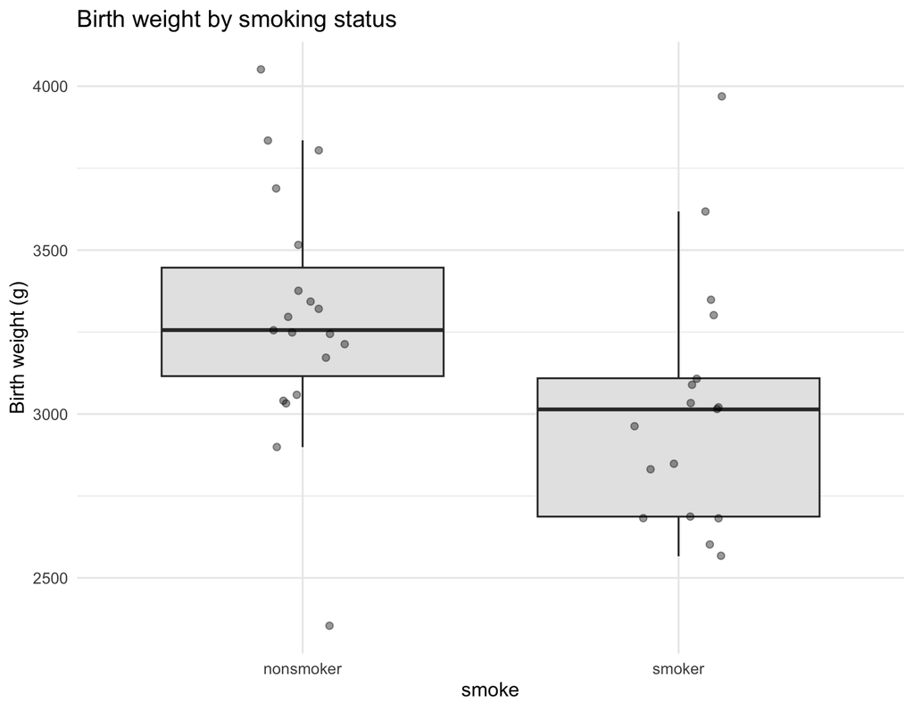

```r
ggplot(cat_binary, aes(smoke, birth_weight)) +
  geom_boxplot(outlier.shape = NA, fill = "grey90") +
  geom_jitter(width = 0.12, alpha = 0.4, size = 2) +
  labs(title = "Birth weight by smoking status", y = "Birth weight (g)") +
  theme_minimal(base_size = 14)
```

```r
cat_binary_model <- lm(birth_weight ~ smoke, data = cat_binary)
summary(cat_binary_model)
```

```
##
## Call:
## lm(formula = birth_weight ~ smoke, data = cat_binary)
##
## Residuals:
##     Min      1Q  Median      3Q     Max
## -947.47 -248.22  -26.94  119.07  947.59
##
## Coefficients:
##             Estimate Std. Error t value Pr(>|t|)
## (Intercept)  3302.47      86.56  38.154   <2e-16 ***
## smokesmoker  -281.06     125.96  -2.231   0.0324 *
## ---
## Signif. codes:  0 '***' 0.001 '**' 0.01 '*' 0.05 '.' 0.1 ' ' 1
##
## Residual standard error: 377.3 on 34 degrees of freedom
## Multiple R-squared:  0.1277, Adjusted R-squared:  0.1021
## F-statistic: 4.979 on 1 and 34 DF,  p-value: 0.03235
```

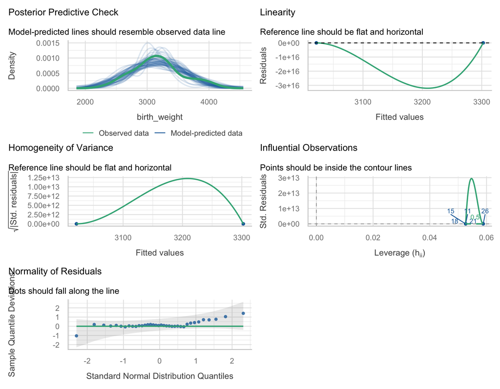

```r
check_model(cat_binary_model)
```

To show only the panels that apply:

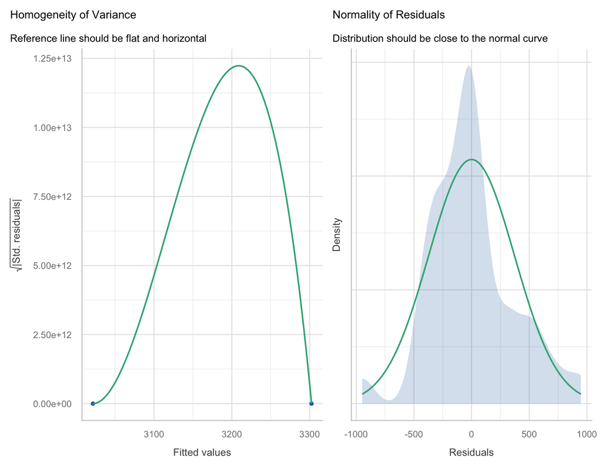

```r
check_model(cat_binary_model, check = c("homogeneity", "normality"))
```

Look at the **Homogeneity of variance** panel:

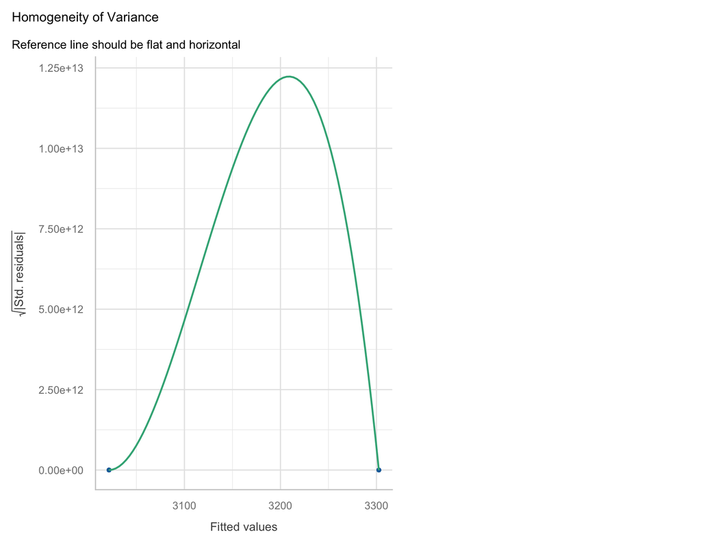

```r
check_model(cat_binary_model, check = "homogeneity")
```

There are only two fitted values (one per group), but `check_model()` still draws a smooth curve through them. Interpolating between two points is unstable, so the green line can shoot up to extreme values. That does not mean the model is wrong; the line just does not make sense here. The dots are still the residuals you would compare across groups.

For the actual check, use base R instead:

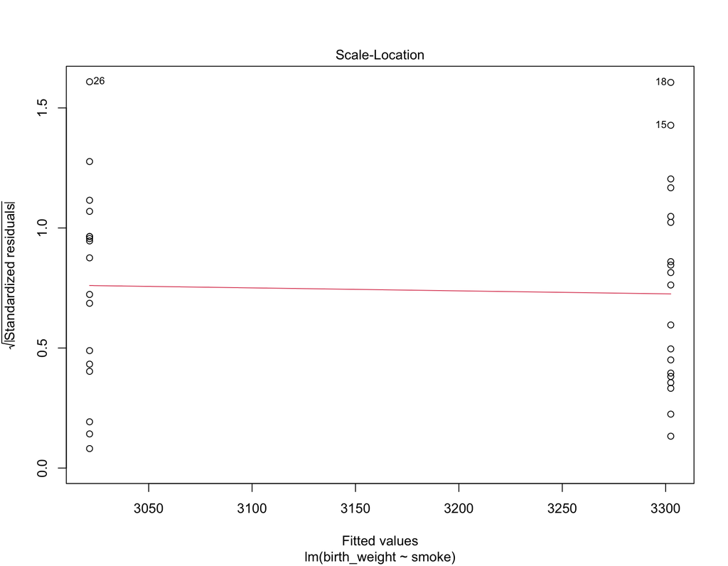

```r
plot(cat_binary_model, which = 3)
```

The plot shows two vertical strips of points, one per group.

The two strips are similar in height.

```r
cat_binary %>%
  group_by(smoke) %>%
  summarise(mean = mean(birth_weight), sd = sd(birth_weight), n = n())
```

| smoke | mean | sd | n |
| --- | --- | --- | --- |
| nonsmoker | 3302.474 | 379.4248 | 19 |
| smoker | 3021.412 | 374.8717 | 17 |

The standard deviations are similar, so the equal-variance assumption is satisfied.

### ICU length of stay by admission type (unequal spread)

ICU length of stay (days) for elective vs. emergency admissions.

Elective admissions have shorter, more predictable stays. Emergency admissions vary more widely.

```r
cat_hom_bad <- data.frame(
  admission = factor(rep(c("elective", "emergency"), c(18, 18)),
                     levels = c("elective", "emergency")),
  los_days = c(3.4, 6.7, 5.1, 4.3, 3.8, 6, 3.9, 3.8, 3.8, 4.3, 3.2, 4.1, 4.8, 3.9, 3.1, 3, 4.9, 6.2,
               11.2, 0.5, 4.4, 7, 4, 2.3, 4.6, 9.5, 8.1, 2.9, 10.7, 0.5, 9.4, 1.3, 9.9, 4.6, 2.4, 3.4)
)
```

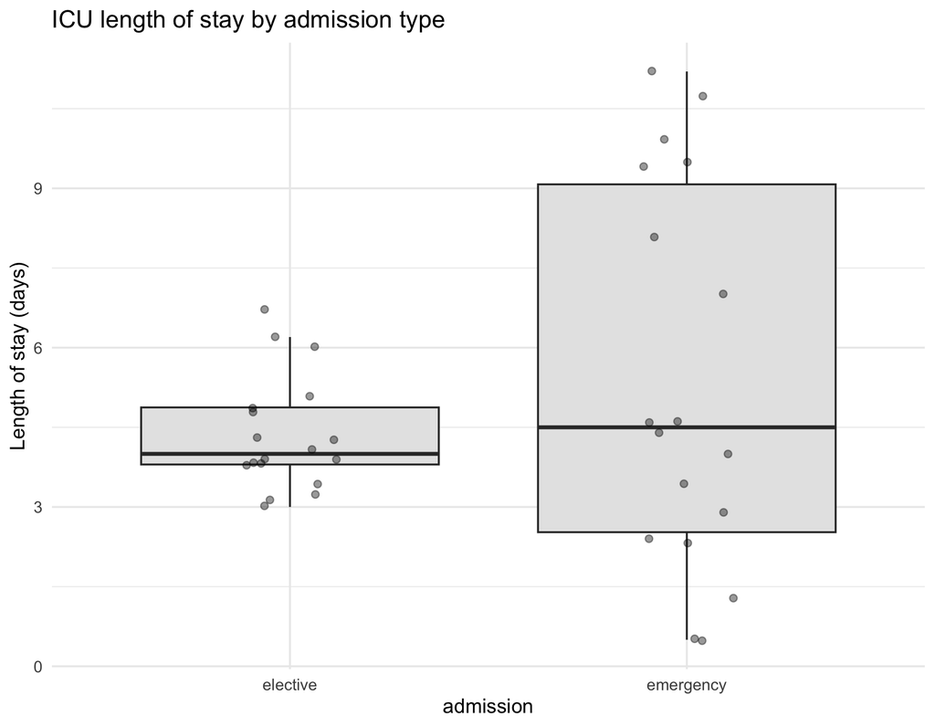

```r
ggplot(cat_hom_bad, aes(admission, los_days)) +
  geom_boxplot(outlier.shape = NA, fill = "grey90") +
  geom_jitter(width = 0.12, alpha = 0.4, size = 2) +
  labs(title = "ICU length of stay by admission type", y = "Length of stay (days)") +
  theme_minimal(base_size = 14)
```

```r
cat_hom_bad_model <- lm(los_days ~ admission, data = cat_hom_bad)
summary(cat_hom_bad_model)
```

```
##
## Call:
## lm(formula = los_days ~ admission, data = cat_hom_bad)
##
## Residuals:
##    Min     1Q Median     3Q    Max
## -4.872 -1.275 -0.500  1.633  5.828
##
## Coefficients:
##                    Estimate Std. Error t value Pr(>|t|)
## (Intercept)          4.3500     0.6292   6.914 5.75e-08 ***
## admissionemergency   1.0222     0.8898   1.149    0.259
## ---
## Signif. codes:  0 '***' 0.001 '**' 0.01 '*' 0.05 '.' 0.1 ' ' 1
##
## Residual standard error: 2.669 on 34 degrees of freedom
## Multiple R-squared:  0.03737,    Adjusted R-squared:  0.009053
## F-statistic:  1.32 on 1 and 34 DF,  p-value: 0.2587
```

Use the base R scale-location plot to compare spread across groups:

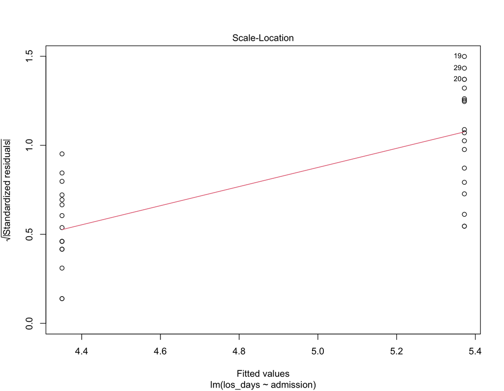

```r
plot(cat_hom_bad_model, which = 3)
```

```r
cat_hom_bad %>%
  group_by(admission) %>%
  summarise(mean = mean(los_days), sd = sd(los_days), n = n())
```

| admission | mean | sd | n |
| --- | --- | --- | --- |
| elective | 4.350000 | 1.077169 | 18 |
| emergency | 5.372222 | 3.618223 | 18 |

The emergency strip is taller than the elective strip, and the standard deviations confirm unequal spread.

The homogeneity assumption is violated.

Because the plot and standard deviations already show the problem, we can confirm with the formal test:

```r
check_heteroscedasticity(cat_hom_bad_model)
```

[output not shown]

**One way to fix it:** with two groups, the standard solution is Welch’s t-test (`t.test()` in base R, which uses Welch’s version by default). It compares the two means without assuming equal variances, so the unequal spread stops being a problem.

### Practice

A clinical trial of a blood-pressure drug. Systolic blood pressure (mmHg) for patients on placebo vs. the active drug.

Fit the model, look at the boxplot, then read the **Homogeneity of variance** panel in `check_model()`. Use `check_model(model, check = "homogeneity")` to hide the other panels, and `plot(model, which = 3)` to compare spread across groups. Is the spread similar in each group?

```r
practice_5 <- data.frame(
  treatment = factor(rep(c("placebo", "drug"), c(18, 18)),
                     levels = c("placebo", "drug")),
  systolic_bp = c(141, 142, 151, 141, 123, 146, 135, 149, 149, 132, 144, 142, 159, 144, 148, 142, 141, 145,
                  132, 126, 127, 134, 138, 135, 133, 133, 136, 149, 114, 123, 145, 132, 129, 138, 129, 144)
)
```

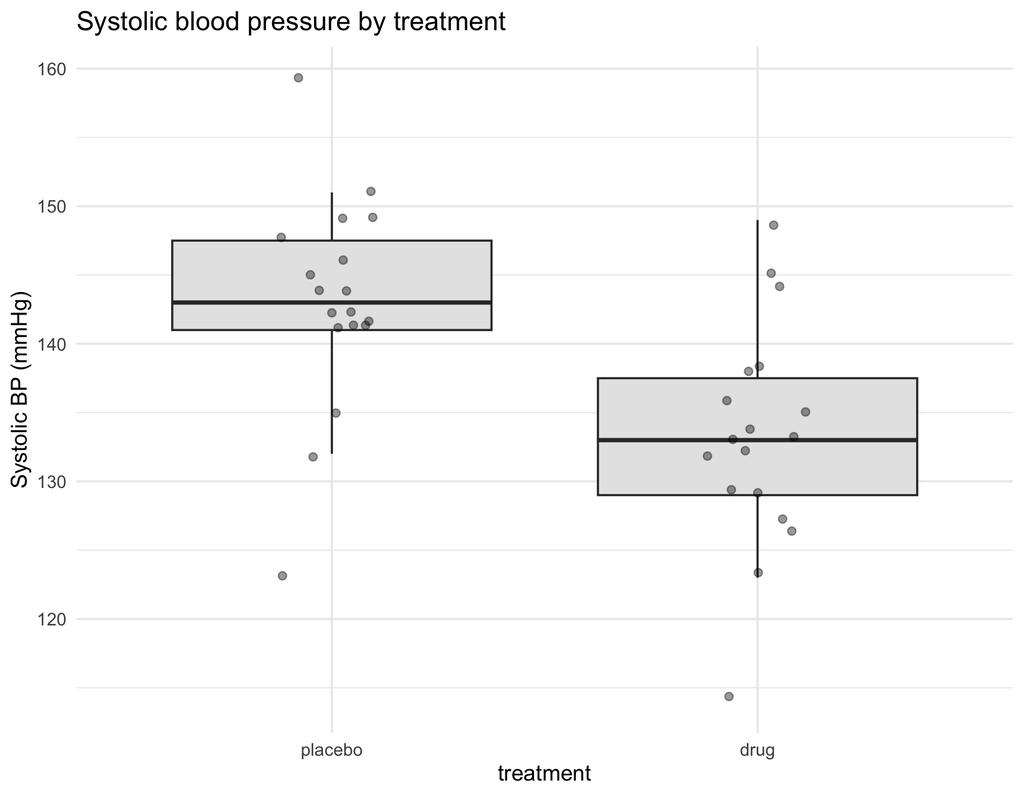

```r
ggplot(practice_5, aes(treatment, systolic_bp)) +
  geom_boxplot(outlier.shape = NA, fill = "grey90") +
  geom_jitter(width = 0.12, alpha = 0.4, size = 2) +
  labs(title = "Systolic blood pressure by treatment", y = "Systolic BP (mmHg)") +
  theme_minimal(base_size = 14)
```

```r
practice_5_model <- lm(systolic_bp ~ treatment, data = practice_5)
summary(practice_5_model)
```

```
##
## Call:
## lm(formula = systolic_bp ~ treatment, data = practice_5)
##
## Residuals:
##      Min       1Q   Median       3Q      Max
## -20.0000  -2.5417  -0.1667   4.8333  16.0000
##
## Coefficients:
##               Estimate Std. Error t value Pr(>|t|)
## (Intercept)    143.000      1.894   75.48  < 2e-16 ***
## treatmentdrug   -9.833      2.679   -3.67 0.000824 ***
## ---
## Signif. codes:  0 '***' 0.001 '**' 0.01 '*' 0.05 '.' 0.1 ' ' 1
##
## Residual standard error: 8.038 on 34 degrees of freedom
## Multiple R-squared:  0.2838, Adjusted R-squared:  0.2627
## F-statistic: 13.47 on 1 and 34 DF,  p-value: 0.0008239
```

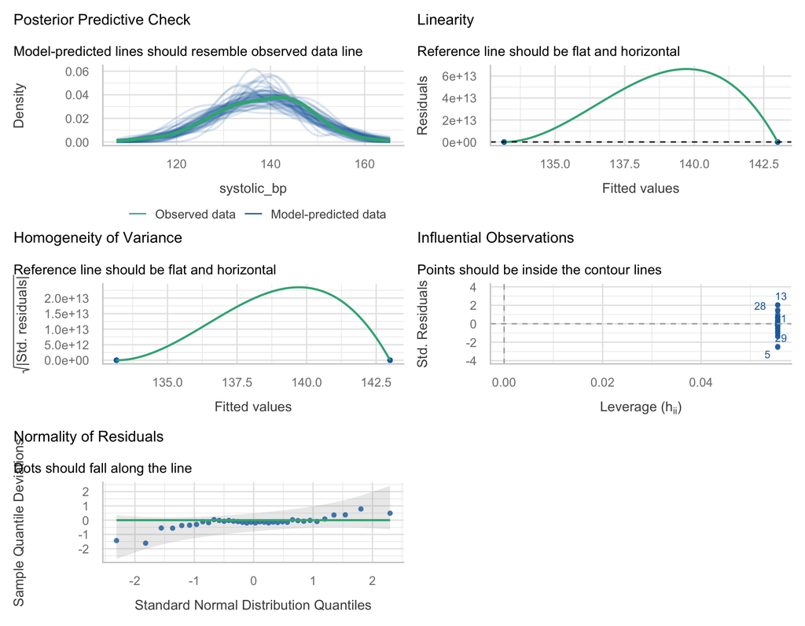

```r
check_model(practice_5_model)
```

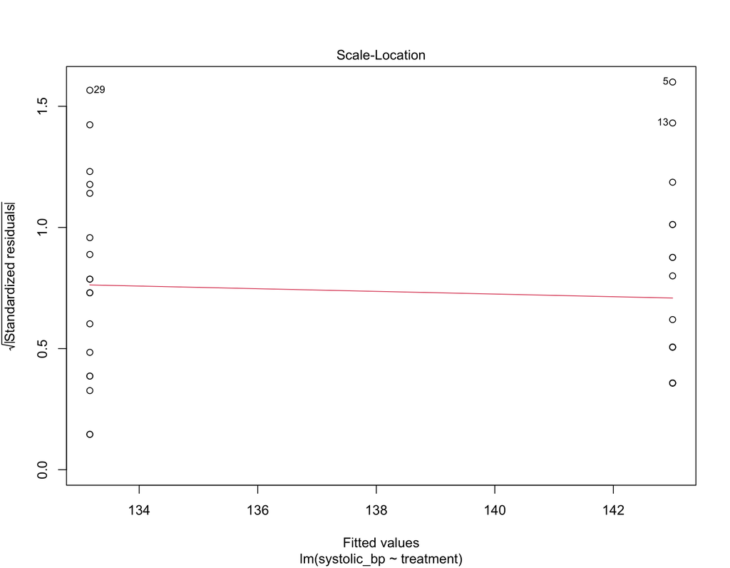

```r
plot(practice_5_model, which = 3)
```

**Your answer here:**

## N: Normality of Residuals

**The question:** are the residuals roughly bell-shaped?

We read the **Normality of residuals** panel in `check_model()`.

### Birth weight by smoking status (normal residuals)

Using the birth weight data from above.

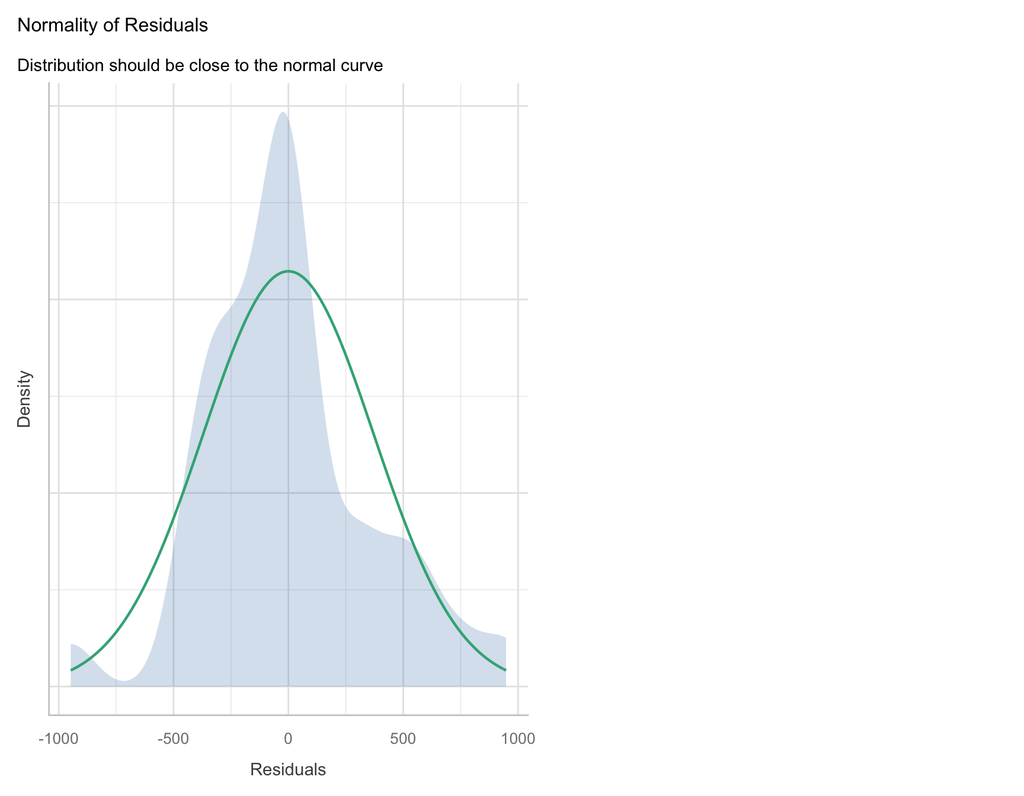

```r
check_model(cat_binary_model, check = "normality")
```

The Q-Q points lie close to the reference line.

### Hospital charges by insurance type (non-normal residuals)

Total hospital charges (USD) for privately insured vs. publicly insured patients.

```r
cat_bin_norm_bad <- data.frame(
  insurance = factor(rep(c("public", "private"), c(20, 20)),
                     levels = c("public", "private")),
  charges = c(4200, 5100, 4800, 5300, 4600, 4900, 5200, 4500, 5000, 4700, 5100, 4400, 4900, 4600, 5200, 4800, 5000, 4700, 5100, 4900,
              8200, 9100, 7800, 9500, 8600, 8800, 9200, 8400, 8900, 8700, 9000, 8300, 8800, 8500, 9100, 8600, 8900, 8400, 8700, 28500)
)
```

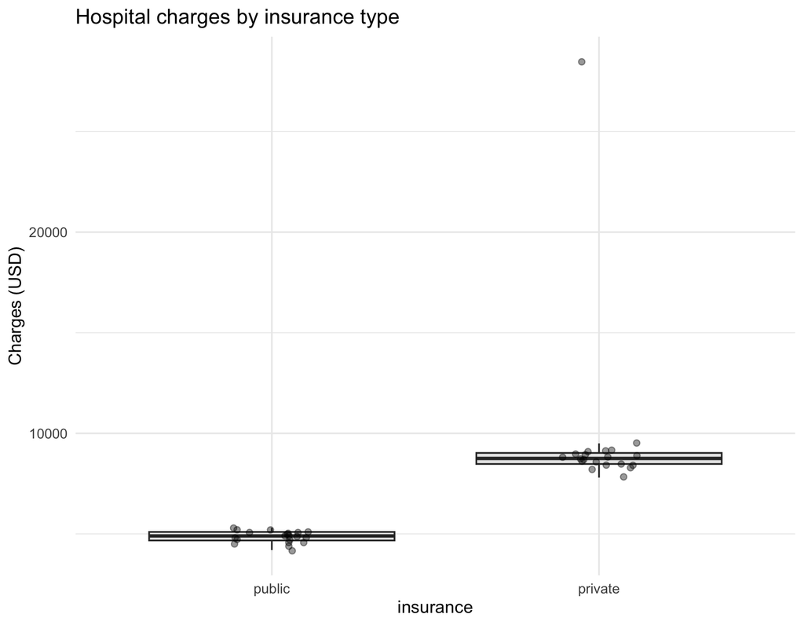

```r
ggplot(cat_bin_norm_bad, aes(insurance, charges)) +
  geom_boxplot(outlier.shape = NA, fill = "grey90") +
  geom_jitter(width = 0.12, alpha = 0.4, size = 2) +
  labs(title = "Hospital charges by insurance type", y = "Charges (USD)") +
  theme_minimal(base_size = 14)
```

```r
cat_bin_norm_bad_model <- lm(charges ~ insurance, data = cat_bin_norm_bad)
summary(cat_bin_norm_bad_model)
```

```
##
## Call:
## lm(formula = charges ~ insurance, data = cat_bin_norm_bad)
##
## Residuals:
##    Min     1Q Median     3Q    Max
##  -1900   -925   -400     50  18800
##
## Coefficients:
##                  Estimate Std. Error t value Pr(>|t|)
## (Intercept)        4850.0      703.9   6.891 3.46e-08 ***
## insuranceprivate   4850.0      995.4   4.872 1.98e-05 ***
## ---
## Signif. codes:  0 '***' 0.001 '**' 0.01 '*' 0.05 '.' 0.1 ' ' 1
##
## Residual standard error: 3148 on 38 degrees of freedom
## Multiple R-squared:  0.3845, Adjusted R-squared:  0.3683
## F-statistic: 23.74 on 1 and 38 DF,  p-value: 1.976e-05
```

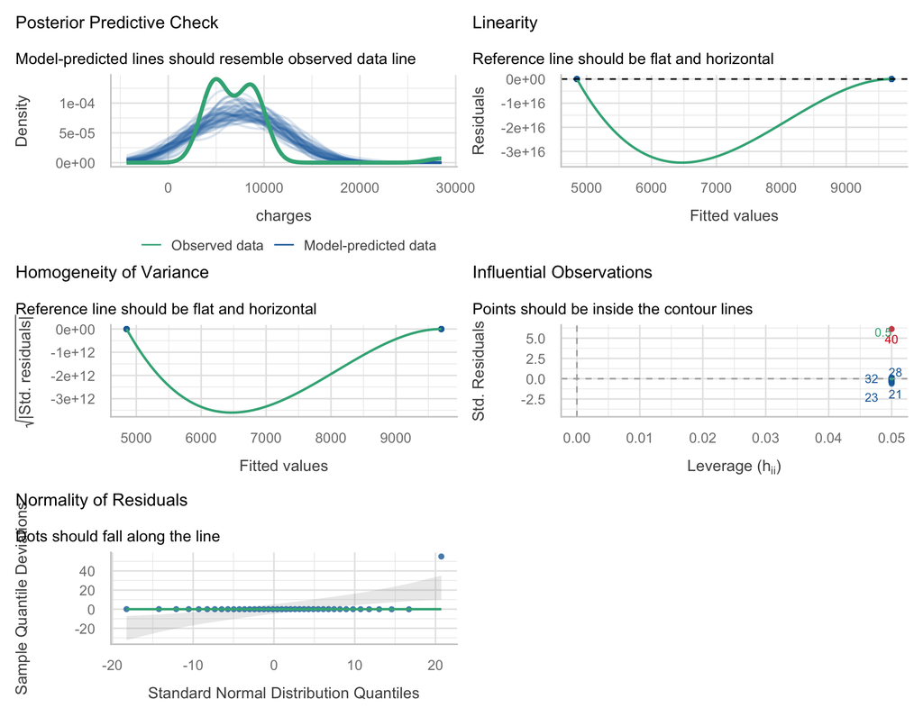

```r
check_model(cat_bin_norm_bad_model)
```

To show only the normality panel:

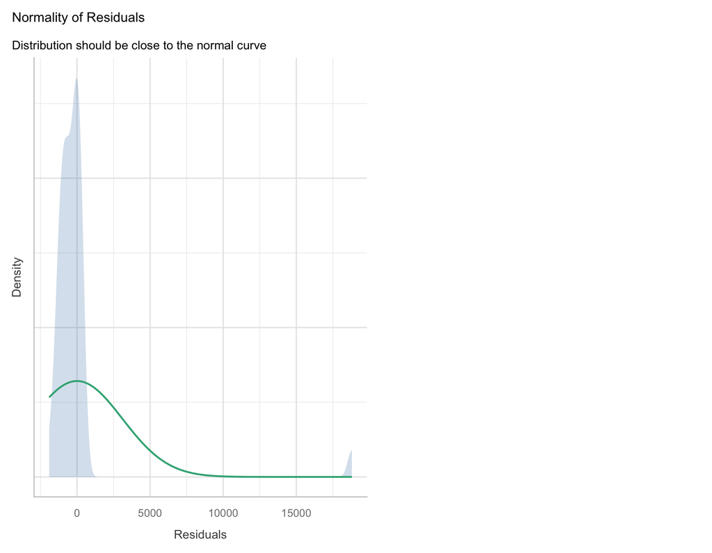

```r
check_model(cat_bin_norm_bad_model, check = "normality")
```

In the *Normality* Q-Q panel, the points bend away from the reference line at the upper end.

That is the long right tail from the high charge values.

Because the Q-Q plot already shows the bend, we can confirm with the formal test:

```r
check_normality(cat_bin_norm_bad_model)
```

[output not shown]

**One way to fix it:** inspect the extreme value first; a charge of 28,500 among values around 8,000 to 9,000 may be a data-entry error or a genuinely unusual patient. If it is genuine and skew is a general feature of the outcome (as it often is with costs), a log transformation of the outcome is the usual first step.

### Practice

Peak expiratory flow (L/min) for patients with vs. without a chronic respiratory condition.

Fit the model, look at the boxplot, then read the **Normality of residuals** panel in `check_model()`. Use `check_model(model, check = "normality")` if you want to hide the other panels. Are the residuals roughly bell-shaped?

```r
practice_8 <- data.frame(
  condition = factor(rep(c("none", "chronic"), c(18, 18)),
                     levels = c("none", "chronic")),
  peak_flow = c(420, 435, 410, 445, 430, 425, 440, 415, 450, 428, 438, 422, 442, 418, 448, 432, 426, 444,
                310, 325, 305, 330, 315, 320, 328, 308, 332, 312, 318, 322, 326, 310, 324, 316, 320, 314)
)
```

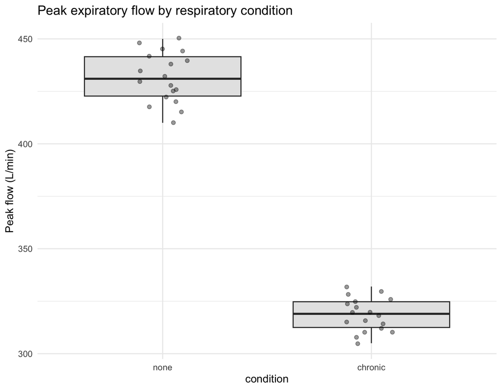

```r
ggplot(practice_8, aes(condition, peak_flow)) +
  geom_boxplot(outlier.shape = NA, fill = "grey90") +
  geom_jitter(width = 0.12, alpha = 0.4, size = 2) +
  labs(title = "Peak expiratory flow by respiratory condition", y = "Peak flow (L/min)") +
  theme_minimal(base_size = 14)
```

```r
practice_8_model <- lm(peak_flow ~ condition, data = practice_8)
summary(practice_8_model)
```

```
##
## Call:
## lm(formula = peak_flow ~ condition, data = practice_8)
##
## Residuals:
##      Min       1Q   Median       3Q      Max
## -21.5556  -7.1111  -0.0833   7.6528  18.4444
##
## Coefficients:
##                  Estimate Std. Error t value Pr(>|t|)
## (Intercept)       431.556      2.386  180.85   <2e-16 ***
## conditionchronic -112.944      3.375  -33.47   <2e-16 ***
## ---
## Signif. codes:  0 '***' 0.001 '**' 0.01 '*' 0.05 '.' 0.1 ' ' 1
##
## Residual standard error: 10.12 on 34 degrees of freedom
## Multiple R-squared:  0.9705, Adjusted R-squared:  0.9697
## F-statistic:  1120 on 1 and 34 DF,  p-value: < 2.2e-16
```

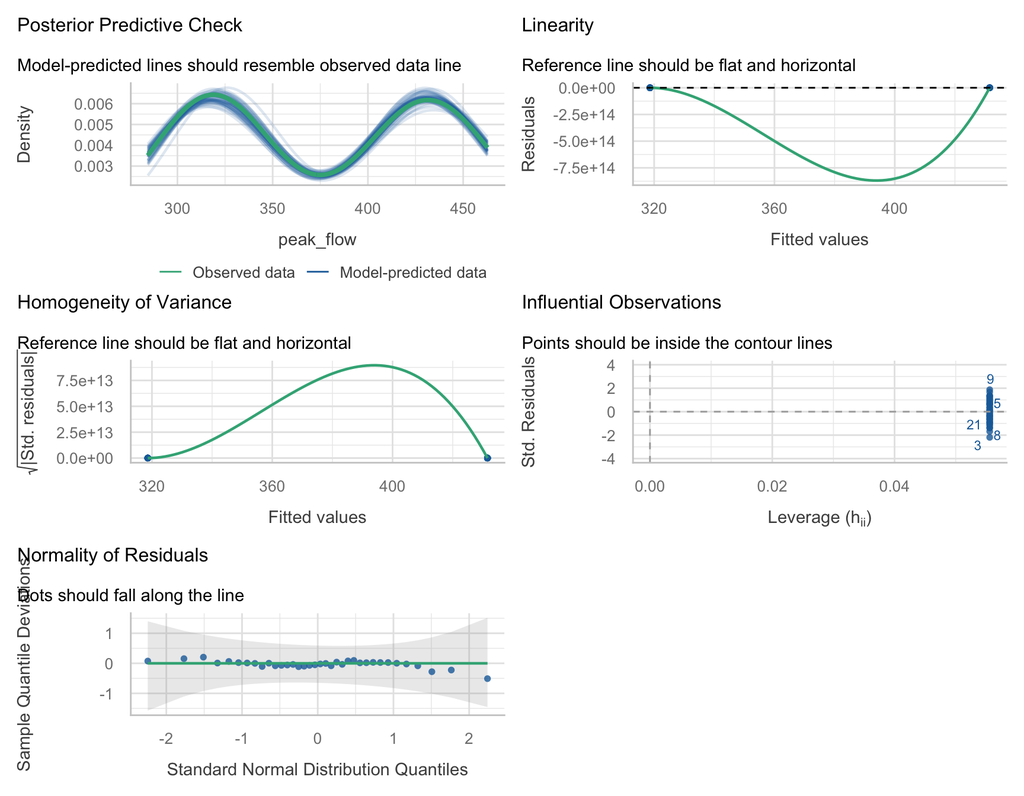

```r
check_model(practice_8_model)
```

**Your answer here:**